# Sensitivity Analysis Earth System configuration of JULES

Doug McNeall

09/08/2021

## 0.1 Preliminaries

Load libraries, functions and data.

```r
# Load helper functions

knitr::opts_chunk$set(fig.path = "figs/", echo = TRUE, message = FALSE, warnings = FALSE)

# load helper functions, data and do preliminary processing of the ensemble.
source('JULES-ES-1p0-common.R')
```

```r
library(sensitivity)
```

```r
# Helper functions

# rotate a matric 90 degrees clockwise for plotting
rotate <- function(x) t(apply(x, 2, rev))



sensvar = function(oaat_pred, n, d){
  # Calculate variance as a global sensitivity meansure
  out = rep(NA,d)
  for(i in 1:d){
    ix = seq(from = ((i*n) - (n-1)), to =  (i*n), by = 1)
    out[i] = var(oaat_pred$mean[ix])
  }
  out
}


twoStep_sens <- function(X, y, n=21, predtype = 'UK', nugget=NULL, nuggetEstim=FALSE, noiseVar=NULL, seed=NULL, trace=FALSE, maxit=100,
                        REPORT=10, factr=1e7, pgtol=0.0, parinit=NULL, popsize=100){
  # Sensitivity analysis with twoStep emulator.
  # Calculates the variance of the output varied one at a time across each input.
  d = ncol(X)
  X_norm <- normalize(X)
  X_oaat <- oaat_design(X_norm, n, med = TRUE)
  colnames(X_oaat) = colnames(X)

  twoStep_em = twoStep_glmnet(X=X, y=y, nugget=nugget, nuggetEstim=nuggetEstim, noiseVar=noiseVar,
                              seed=seed, trace=trace, maxit=maxit,
                              REPORT=REPORT, factr=factr, pgtol=pgtol,
                              parinit=parinit, popsize=popsize)

  oaat_pred = predict(twoStep_em$emulator, newdata = X_oaat, type = predtype)

  sens = sensvar(oaat_pred = oaat_pred, n=n, d=d)
  out = sens
  out
}



oaatSensvarKm <- function(X, y, n = 21, med = TRUE, hold = NULL,  formula = ~., predtype = 'UK', ...){
  # one-at-a-time sensitivity summary with a standard dicekriging emulator

  d = ncol(X)
  X_norm <- normalize(X)
  X_oaat <- oaat_design(X_norm, n, med = med, hold = hold)
  colnames(X_oaat) = colnames(X)


  em <- km(formula = formula, design = X, response = y, ...)

  oaat_pred = predict(em, newdata = X_oaat, type = predtype)

  sens = sensvar(oaat_pred = oaat_pred, n=n, d=d)
  out = sens
  out

}

oaatSensvarKmList <- function(X, em_list, n = 21, med = TRUE, hold = NULL,  formula = ~., predtype = 'UK', ...){
  # one-at-a-time sensitivity summary with a standard dicekriging emulator

  d = ncol(X)
  X_oaat <- oaat_design(X, n, med = med, hold = hold)
  colnames(X_oaat) = colnames(X)

  em <- em_list[[i]]

  oaat_pred = predict(em, newdata = X_oaat, type = predtype)

  sens = sensvar(oaat_pred = oaat_pred, n=n, d=d)
  out = sens
  out

}





oaatSensvarSummaryPlot <- function(oat_sens_mat){

  # relies on rotate(), fields,  which need sorting for transfer to package

  ynames <- rownames(oat_sens_mat)
  xnames <- colnames(oat_sens_mat)

  normsens <- normalize(t(oat_sens_mat))
  normsens_mean <- apply(normsens,1, mean)

  sort_ix <- sort(normsens_mean, decreasing = TRUE, index.return = TRUE)

  par(mar = c(15,12,5,1), mfrow = c(1,2))

  layout(matrix(c(1,1,2), ncol = 3, nrow = 1))

  image(rotate(normsens[sort_ix$ix, ]), axes = FALSE, col = blues)

  axis(1, at = seq(from = 0, to = 1, length.out = length(ynames)), labels = ynames, las = 3, cex.axis = 1.2)
  axis(2, at = seq(from = 1, to = 0, length.out = length(xnames)), labels = xnames[sort_ix$ix], las = 1, cex.axis = 1.2)
  mtext('One-at-a-time sensitivity', side = 3, adj = 0, line = 2, cex = 1)

  lab_ix <- (1:length(xnames)) - 0.5

  par(yaxs = 'i', mar = c(15,1,5,5))
  plot(rev(normsens_mean[sort_ix$ix]), lab_ix, xlab = 'mean oaat variance (normalized)', ylab = '', ylim = c(0,length(xnames)), type = 'n', yaxt = 'n')
  abline(h = lab_ix, col = 'grey', lty = 'dashed')
  points( rev(normsens_mean[sort_ix$ix]),lab_ix, col = zissou5[1], pch = 19, cex = 1.5)

  image.plot(legend.only = TRUE,
             zlim = c(0,1),
             col = blues,
             legend.args = list(text = 'Relative sensitivity', side = 3, line = 1),
             horizontal = TRUE
  )

}




sensMatSummaryPlot <- function(sens_mat, col = blues, maintext = 'Sensitivity Matrix', xlab = 'sensitivity summary'){
  # Summary plots of a sensitivity matrix


  # relies on rotate(), fields,  which need sorting for transfer to package

  ynames <- rownames(sens_mat)
  xnames <- colnames(sens_mat)

  normsens <- normalize(t(sens_mat))
  normsens_mean <- apply(normsens,1, mean)

  sort_ix <- sort(normsens_mean, decreasing = TRUE, index.return = TRUE)

  par(mar = c(15,12,5,1), mfrow = c(1,2))

  layout(matrix(c(1,1,2), ncol = 3, nrow = 1))

  image(rotate(normsens[sort_ix$ix, ]), axes = FALSE, col = col)

  axis(1, at = seq(from = 0, to = 1, length.out = length(ynames)), labels = ynames, las = 3, cex.axis = 1.2)
  axis(2, at = seq(from = 1, to = 0, length.out = length(xnames)), labels = xnames[sort_ix$ix], las = 1, cex.axis = 1.2)
  mtext(maintext, side = 3, adj = 0, line = 2, cex = 1)

  lab_ix <- (1:length(xnames)) - 0.5

  par(yaxs = 'i', mar = c(15,1,5,5))
  plot(rev(normsens_mean[sort_ix$ix]), lab_ix, xlab = xlab, ylab = '', ylim = c(0,length(xnames)), type = 'n', yaxt = 'n')
  abline(h = lab_ix, col = 'grey', lty = 'dashed')
  points( rev(normsens_mean[sort_ix$ix]),lab_ix, col = zissou5[1], pch = 19, cex = 1.5)

  image.plot(legend.only = TRUE,
             zlim = c(0,1),
             col = col,
             legend.args = list(text = 'Relative sensitivity', side = 3, line = 1),
             horizontal = TRUE
  )
}




bp_convert <- function(fastmodel){
  # get the FAST summary into an easier format for barplot
  fast_summ <- print(fastmodel)
  fast_diff <- fast_summ[ ,2] - fast_summ[ ,1]
  fast_bp <- t(cbind(fast_summ[ ,1], fast_diff))
  fast_bp
}


multiFAST<- function(X, Y, fit_list = NULL, n = 1000){

  # Generate a design for the FAST99 analysis
  X_fast <- fast99(model = NULL, factors = colnames(X), n = n,
                   q = "qunif", q.arg = list(min = 0, max = 1))


  if(is.null(fit_list)){
    fit_list <- createKmFitList(X = X, Y = Y)
  }

  else{
  fit_list <- fit_list
  }

  fast_tell_list <- vector(mode = 'list', length = ncol(Y))


  for(i in 1:ncol(Y)){

    fit <- fit_list[[i]]
    # Predict the response at the FAST99 design points using the emulator
    pred_fast <- predict(fit, newdata = X_fast$X, type = 'UK')

    # Calculate the sensitivity indices
    fast_tell <- tell(X_fast, pred_fast$mean)

    fast_tell_list[[i]] <- fast_tell

  }

  return(list(fit_list = fit_list, fast_tell_list = fast_tell_list))

}

oaatSensvarRank <- function(oat_sens_mat){

  ynames <- rownames(oat_sens_mat)
  xnames <- colnames(oat_sens_mat)

  normsens <- normalize(t(oat_sens_mat))
  normsens_mean <- apply(normsens,1, mean)

  rank <- rank(-normsens_mean)


  return(list(mean = normsens_mean, rank = rank))

}

SensRank <- function(sens_mat){

  # summarising and ranking parameters in a sensitivity matrix

  ynames <- rownames(sens_mat)
  xnames <- colnames(sens_mat)

  normsens <- normalize(t(sens_mat))
  normsens_mean <- apply(normsens,1, mean)

  rank <- rank(-normsens_mean)

  return(list(mean = normsens_mean, rank = rank))

}
```

to find the “standard” value in normalized space, we can normalize a vector of “1s” with respect to the original design

```r
X_standard <- matrix(rep(1,d), ncol = d, nrow = 1)

X_standard_norm <- normalize(X_standard, wrt = lhs)

X_level1a_unnorm <- unnormalize(X_level1a, un.mins = lhs_min, un.maxes = lhs_max)

X_level1a_wave01_unnorm <- unnormalize(X_level1a_wave01, un.mins = lhs_min, un.maxes = lhs_max)
```

# 1 Sensitivity at level1a constraint (f0_io and b_wl_io truncated)

Define constraint level 1a as those members that run, and have F0_io <0.9 & b_wl_io > 0.15 (normalised).

## 1.1 Modern value sensitivity

```r
#if (file.exists("oaat_level1a_Y.rdata")) {
#  load("oaat_level1a_Y.rdata")
#} else {

oat_var_sensmat_level1a_Y <- matrix(NA, nrow = length(y_names_sum), ncol = ncol(X_level1a))

for(i in 1:length(y_names_sum)){

  yname <- y_names_sum[i]
  y <- Y_level1a[, yname]
  oat <- oaatSensvarKmList(X = X_level1a, em_list = emlist_km_Y_level1a, med = FALSE, hold = X_standard_norm)
  oat_var_sensmat_level1a_Y[i, ] <- oat
}

#save(y_names_sum, oat_var_sensmat_level1a_Y, file = "oaat_level1a_Y.rdata")
#}

rownames(oat_var_sensmat_level1a_Y) <- y_names_sum
colnames(oat_var_sensmat_level1a_Y) <- colnames(X_level1a)

#normsens_level1a_Y <- normalize(t(oat_var_sensmat_level1a_Y))
```

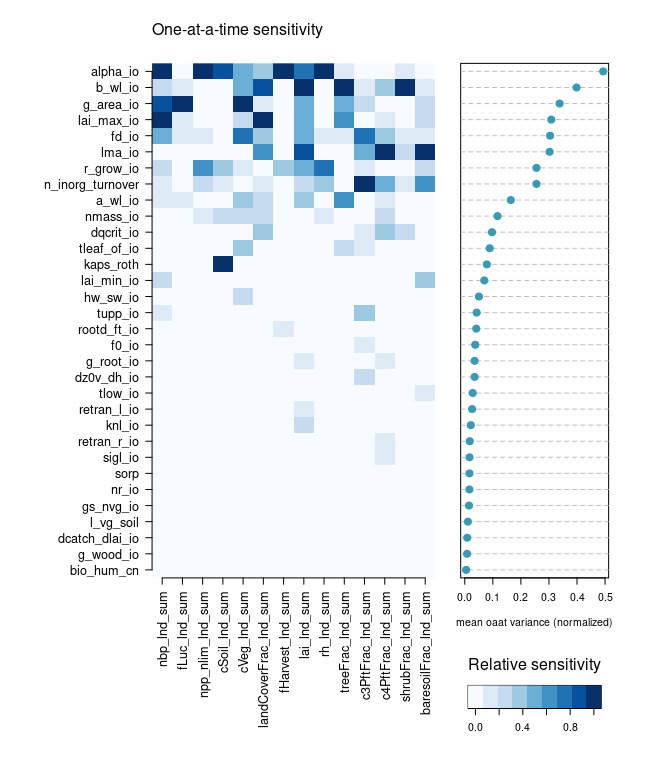

```r
#pdf(file = 'figs/oat_var_sensmat_level1a_Y.pdf', width = 7, height = 8)
oaatSensvarSummaryPlot(oat_var_sensmat_level1a_Y)
```

```r
#dev.off()
```

## 1.2 Anomaly (Change 1850 - 2013) sensitivities

```r
#if (file.exists("oaat_level1a_YAnom.rdata")) {
#  load("oaat_level1a_YAnom.rdata")
#} else {

oat_var_sensmat_level1a_YAnom <- matrix(NA, nrow = length(y_names_sum), ncol = ncol(X_level1a))

for(i in 1:length(y_names_sum)){

  yname <- y_names_sum[i]
  y <- YAnom_level1a[, yname]
  oat <- oaatSensvarKmList(X = X_level1a, em_list = emlist_km_YAnom_level1a,  med = FALSE, hold = X_standard_norm)
  oat_var_sensmat_level1a_YAnom[i, ] <- oat
}

#save(y_names_sum, oat_var_sensmat_level1a_YAnom, file = "oaat_level1a_YAnom.rdata")
#}


rownames(oat_var_sensmat_level1a_YAnom) <- y_names_sum
colnames(oat_var_sensmat_level1a_YAnom) <- colnames(X_level1a)

# Normalise sensitivities
#normsens_level1a_YAnom <- normalize(t(oat_var_sensmat_level1a_YAnom))
```

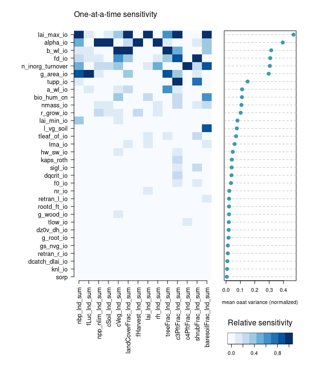

```r
#pdf(file = 'figs/oat_var_sensmat_level1a_YAnom.pdf', width = 7, height = 8)
oaatSensvarSummaryPlot(oat_var_sensmat_level1a_YAnom)
```

```r
#dev.off()
```

## 1.3 One-at-a-time sensitivity analysis of constraining variables for understanding model response

“Constraining variables” being those we use to constrain the model (npp, nbp, cSoil and cVeg). It’s hard to maintain a high vegetation carbon in particular.

Further idea: What parameter values might you choose to do this, and what might be the trade-offs you have to make?

```r
#fit_list_const_level1a <- createKmFitList(X = X_level1a, Y = Y_const_level1a_scaled)

Y_const_level1a_scaled_list <- mat2list(Y_const_level1a_scaled)
fit_list_const_level1a <- mclapply(X = Y_const_level1a_scaled_list, FUN = km, formula = ~., design = X_level1a,
                                   mc.cores = 4, control = list(trace = FALSE))
```

```r
# Check that oatSensVar and the plotting make sense

oaat_sens_cVeg <- oaatSensvarKm(X = X_level1a, y = Y_const_level1a_scaled[,"cVeg_lnd_sum"])
```

[output not shown]

[output cut: 67 more lines]

[output not shown]

```r
X_oaat_level1a <- oaat_design(X_level1a, n=21, med = FALSE, hold = X_standard_norm)

colnames(X_oaat_level1a) = colnames(X)

y_oaat <- predict.km(fit_list_const_level1a[[4]], newdata = X_oaat_level1a, type = 'UK')
```

First, what parameters affect vegetation carbon and how? How sure are we about that?

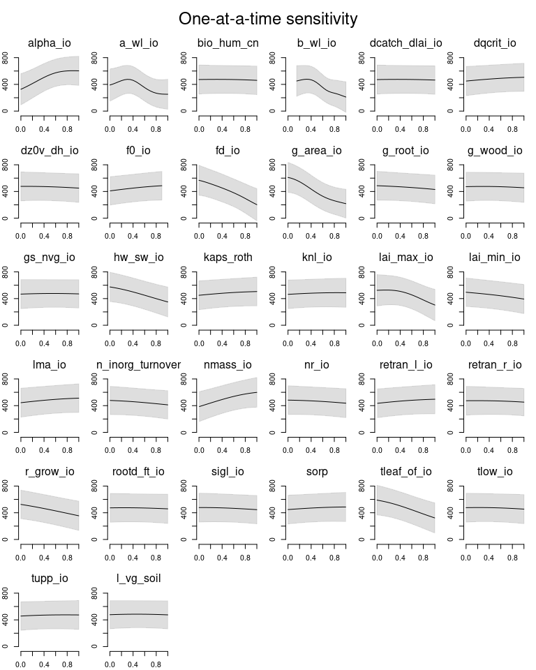

```r
oaatLinePlot(X_oaat = X_oaat_level1a, y_oaat_mean = y_oaat$mean, y_oaat_sd = y_oaat$sd,
             n_oaat = 21,nr = 6, nc = 6)
```

```r
NA
NA
```

```r
Y_oaat_const_level1a_scaled <- matrix(ncol = ncol(Y_const_level1a_scaled), nrow = nrow(X_oaat_level1a))

for(i in 1:ncol(Y_const_level1a_scaled)){

  y_oaat <- predict.km(fit_list_const_level1a[[i]], newdata = X_oaat_level1a, type = 'UK')
  Y_oaat_const_level1a_scaled[,i] <- y_oaat$mean
}
```

What might be the trade-offs for a high (or accurate) vegetation carbon? are they acceptable? Plot the oaat sensitivity of the other 3 outputs we’re calibrating on.

Plotting these graphs in the original input space (multiplication factors) and providing the standard has the pleasing side effect of showing what you could do to standard inputs to increase or decrease a particular output.

```r
Y_oaat_const_level1a_scaled_norm <- normalize(Y_oaat_const_level1a_scaled)

        oaatLinePlotMulti <- function(X_oaat, Y_oaat, n_oaat, nr, nc, cols, ...){

          par(mfrow = c(nr,nc), oma = c(0.1,0.1,3,0.1), mar = c(2,2,3,1), las = 1)

          for(i in 1:ncol(X_oaat)){
            ix <- seq(from = ((i*n_oaat) - (n_oaat-1)), to =  (i*n_oaat), by = 1)

            plot(X_oaat[ix,i], Y_oaat[ix,1],
                 ylim = c(0,1),
                 xlab = colnames(X_oaat)[i],
                 type= 'n',
                 bty = 'n')

            for(j in 1:ncol(Y_oaat)){
              lines(X_oaat[ix,i], Y_oaat[ix, j], lty = 'solid', col = cols[j], ...)
              abline(v = 1, lty = 'dashed', col = 'grey')
              mtext(colnames(X_oaat)[i], side = 3, line = 0.5)

            }

          }

        }

X_oaat_level1a_unnorm <- unnormalize(X_oaat_level1a, un.mins = lhs_min, un.maxes = lhs_max)
#pdf(file = 'figs/Y_oaat_const_level1a_scaled_norm.pdf', width = 10, height = 10)
oaatLinePlotMulti(X_oaat = X_oaat_level1a_unnorm, Y_oaat = Y_oaat_const_level1a_scaled_norm ,  n_oaat = 21, nr = 6, nc = 6,
                  lwd = 3, col = cbPal[c(1,2,6,8)])

reset()
```

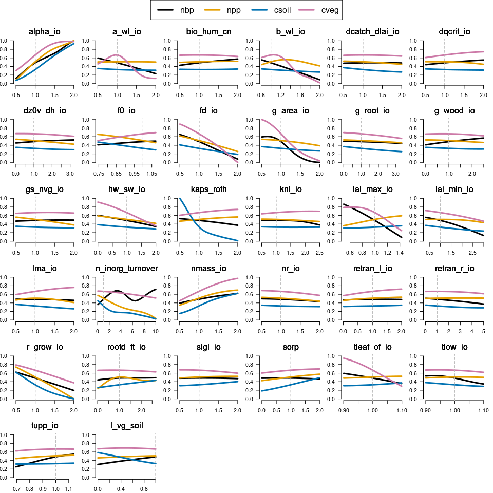

```r
legend('top', c('nbp', 'npp', 'csoil', 'cveg'), col = cbPal[c(1,2,6,8)], lty = 'solid', lwd = 3, horiz = TRUE)
```

```r
#dev.off()
```

## 1.4 Update for wave01

```r
# Build list of emulators for both waves, standard constraint parameters.

Y_const_level1a_wave01_scaled_list <- mat2list(Y_const_level1a_wave01_scaled)
fit_list_const_level1a_wave01 <- mclapply(X = Y_const_level1a_wave01_scaled_list, FUN = km, formula = ~., design = X_level1a_wave01,
                                   mc.cores = 4, control = list(trace = FALSE))
```

```r
Y_oaat_const_level1a_wave01_scaled <- matrix(ncol = ncol(Y_const_level1a_wave01_scaled), nrow = nrow(X_oaat_level1a))

for(i in 1:ncol(Y_oaat_const_level1a_wave01_scaled)){

  y_oaat <- predict.km(fit_list_const_level1a_wave01[[i]], newdata = X_oaat_level1a, type = 'UK')
  Y_oaat_const_level1a_wave01_scaled[,i] <- y_oaat$mean
}
```

```r
Y_oaat_const_level1a_wave01_scaled_norm <- normalize(Y_oaat_const_level1a_wave01_scaled)

#pdf(file = 'figs/Y_oaat_const_level1a_wave01_scaled_norm.pdf', width = 10, height = 10)
oaatLinePlotMulti(X_oaat = X_oaat_level1a_unnorm, Y_oaat = Y_oaat_const_level1a_wave01_scaled_norm ,  n_oaat = 21, nr = 6, nc = 6,
                  lwd = 3, col = cbPal[c(1,2,6,8)])

reset()
```

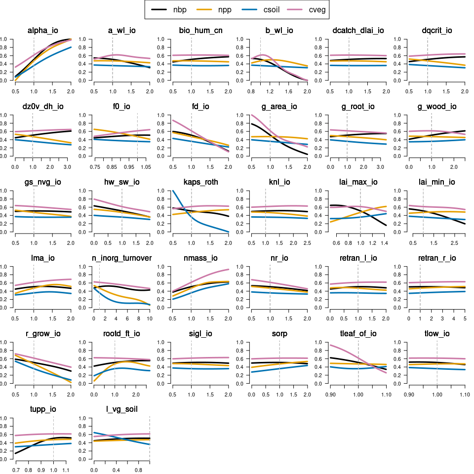

```r
legend('top', c('nbp', 'npp', 'csoil', 'cveg'), col = cbPal[c(1,2,6,8)], lty = 'solid', lwd = 3, horiz = TRUE)
```

```r
#dev.off()
```

```r
Y_sum_level1a_wave01_list <- mat2list(Y_sum_level1a_wave01)

if (file.exists("emlist_km_Y_level1a_wave01_2022-05-24.rdata")) {
  load("emlist_km_Y_level1a_wave01_2022-05-24.rdata")
} else {

  # Here, the list is a list version of the matrix Y_
  emlist_km_Y_level1a_wave01 <- mclapply(X = Y_sum_level1a_wave01_list, FUN = km, formula = ~., design = X_level1a_wave01, mc.cores = 4)

  save( emlist_km_Y_level1a_wave01, file = "emlist_km_Y_level1a_2022-05-24.rdata")

}
```

```r
#if (file.exists("oaat_level1a_Y.rdata")) {
#  load("oaat_level1a_Y.rdata")
#} else {

oat_var_sensmat_level1a_wave01_Y <- matrix(NA, nrow = length(y_names_sum), ncol = ncol(X_level1a))

for(i in 1:length(y_names_sum)){

  yname <- y_names_sum[i]
  y <- Y_level1a[, yname]
  oat <- oaatSensvarKmList(X = X_level1a_wave01, em_list = emlist_km_Y_level1a_wave01, med = FALSE, hold = X_standard_norm)
  oat_var_sensmat_level1a_wave01_Y[i, ] <- oat
}

#save(y_names_sum, oat_var_sensmat_level1a_Y, file = "oaat_level1a_Y.rdata")
#}

rownames(oat_var_sensmat_level1a_wave01_Y) <- y_names_sum
colnames(oat_var_sensmat_level1a_wave01_Y) <- colnames(X_level1a)

#normsens_level1a_Y <- normalize(t(oat_var_sensmat_level1a_Y))
```

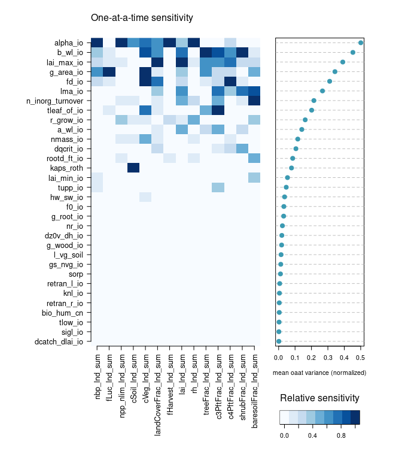

```r
#pdf(file = 'figs/oat_var_sensmat_level1a_wave01_Y.pdf', width = 7, height = 8)
oaatSensvarSummaryPlot(oat_var_sensmat_level1a_wave01_Y)
```

```r
#dev.off()
```

## 1.5 Anomaly wave01

```r
YAnom_sum_level1a_wave01_list <- mat2list(YAnom_sum_level1a_wave01)

if (file.exists("emlist_km_Y_level1a_wave01_2022-05-25.rdata")) {
  load("emlist_km_Y_level1a_wave01_2022-05-25.rdata")
} else {

  # Here, the list is a list version of the matrix Y_
  emlist_km_YAnom_level1a_wave01 <- mclapply(X = YAnom_sum_level1a_wave01_list, FUN = km, formula = ~., design = X_level1a_wave01, mc.cores = 4)

  save( emlist_km_YAnom_level1a_wave01, file = "emlist_km_YAnom_level1a_2022-05-25.rdata")

}
```

```r
oat_var_sensmat_level1a_wave01_YAnom <- matrix(NA, nrow = length(y_names_sum), ncol = ncol(X_level1a))

for(i in 1:length(y_names_sum)){

  yname <- y_names_sum[i]
  y <- Y_level1a[, yname]
  oat <- oaatSensvarKmList(X = X_level1a_wave01, em_list = emlist_km_YAnom_level1a_wave01, med = FALSE, hold = X_standard_norm)
  oat_var_sensmat_level1a_wave01_YAnom[i, ] <- oat
}

#save(y_names_sum, oat_var_sensmat_level1a_Y, file = "oaat_level1a_Y.rdata")
#}

rownames(oat_var_sensmat_level1a_wave01_YAnom) <- y_names_sum
colnames(oat_var_sensmat_level1a_wave01_YAnom) <- colnames(X_level1a)

#normsens_level1a_Y <- normalize(t(oat_var_sensmat_level1a_Y))
```

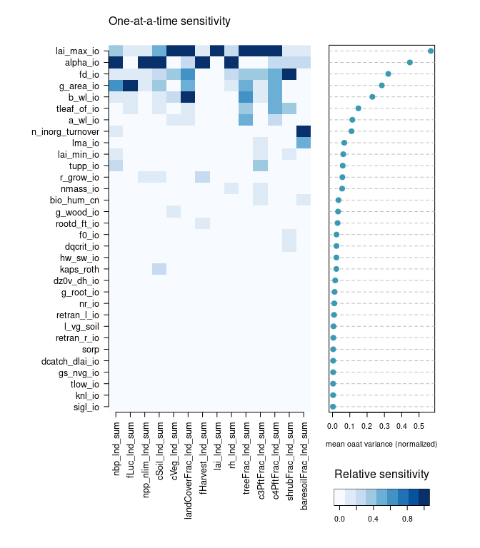

```r
#pdf(file = 'figs/oat_var_sensmat_level1a_wave01_YAnom.pdf', width = 7, height = 8)
oaatSensvarSummaryPlot(oat_var_sensmat_level1a_wave01_YAnom)
```

```r
#dev.off()
```

# 2 FAST sensitivity analysis

We use a FAST99 algorithm by Saltelli et al (2000), from the R package “sensitivity”

```r
# Need to think about how mins and maxes are dealt with - we have a truncated input design

# Generate a design for the FAST99 analysis
X_fast <- fast99(model = NULL, factors = colnames(X_level1a_wave01), n = 3000,
                 q = "qunif", q.arg = list(min = 0, max = 1))
```

Create a list of sensitivity analyses, one for each column of the “sum” (modern) output matrix. (This now uses wave01 data)

```r
MF_Y_sum_level1a <- multiFAST(X = X_level1a_wave01, Y = Y_sum_level1a_wave01, fit_list = emlist_km_Y_level1a_wave01, n = 1000)
```

Create a sensitivity summary matrix from the list of sensitivity analyses.

```r
FAST_total_Y_sum_level1a <- matrix(nrow = length(MF_Y_sum_level1a$fast_tell_list), ncol = d)

for(i in 1:length(MF_Y_sum_level1a$fast_tell_list)){

  # sum the direct effect and interaction terms to get a total
  FAST_total_Y_sum_level1a[i, ] <- apply(bp_convert(MF_Y_sum_level1a$fast_tell_list[[i]]),2,sum)
}
colnames(FAST_total_Y_sum_level1a) <- colnames(X_level1a)
rownames(FAST_total_Y_sum_level1a) <- colnames(Y_sum_level1a)
```

Plot the summary matrix

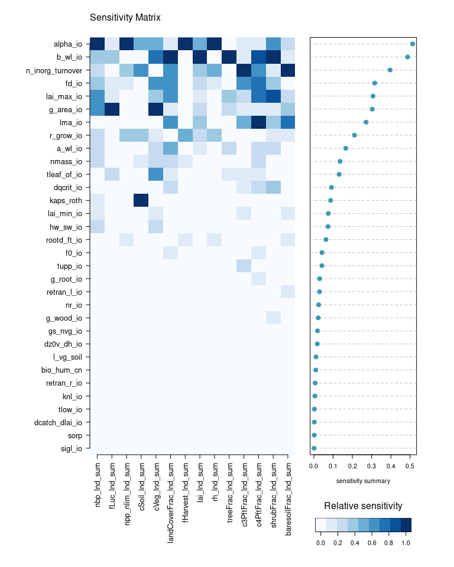

```r
#pdf(file = 'figs/FAST_sensmat_Y_level1a_wave01.pdf', width = 7, height = 8)
sensMatSummaryPlot(FAST_total_Y_sum_level1a)
```

```r
#dev.off()
```

Now create a list of sensitivity analyses for the anomaly at the end of the run.

```r
MF_YAnom_sum_level1a <- multiFAST(X = X_level1a, Y = YAnom_sum_level1a, fit_list = emlist_km_YAnom_level1a)
```

Plot the sensitivity summary matrix

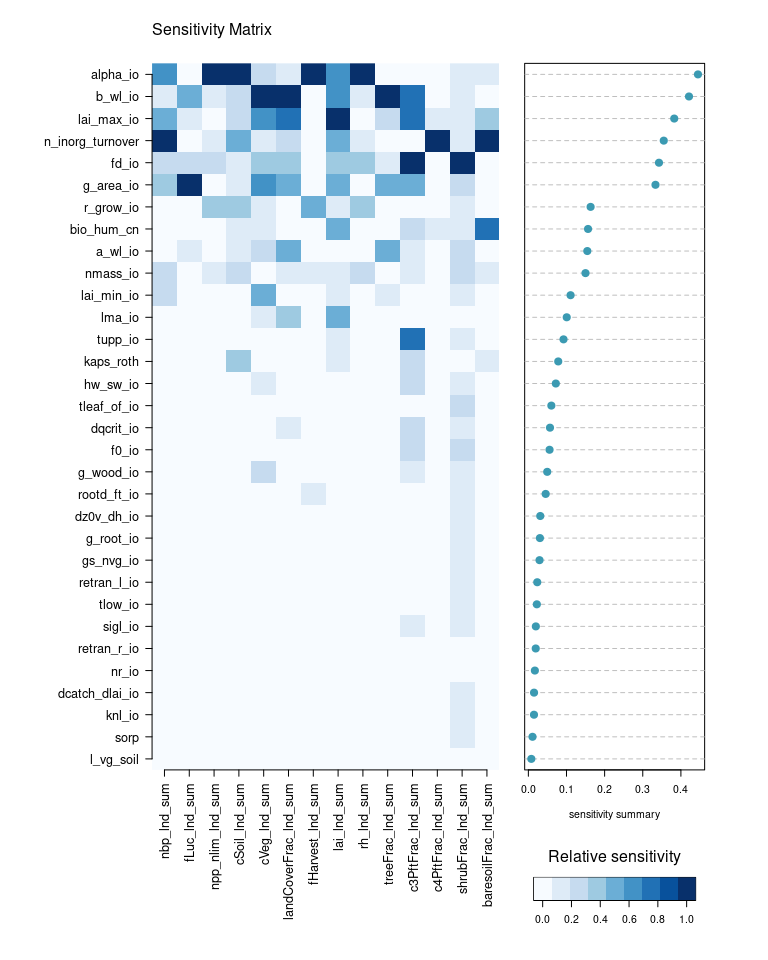

```r
#pdf(file = 'figs/FAST_sensmat_YAnom_level1a_wave01.pdf', width = 7, height = 8)
sensMatSummaryPlot(FAST_total_YAnom_sum_level1a)
```

```r
#dev.off()
```

```r
knit_exit()
```

# 3 Monte Carlo Filtering

```r
# ---------------------------------------------------------------------------------
# Monte carlo filtering for sensitivity analysis
# ---------------------------------------------------------------------------------

# Uniform sample from across parameter space
# Split the sample into 'behavioural' (NROY) and 'Non behavioural (Ruled Out)
# Build cdfs of the marginal distributions in each case
# Perform a KS test to see if the smaples are drawn from different distributions
# The KS statistic is an indicator of the importance of the parameter in splitting the
# samples.

# "Not in" function
'%!in%' <- function(x,y)!('%in%'(x,y))

mcf = function(X, nroy_ix){

  ## Monte Carlo Filtering function
  ## X   ............... Complete sample from input space
  ## nroy.ix ........... index of cases of X which are NROY (Not Ruled Out Yet), or 'behavioural'.

  ## produces ks statistic for each column of the input matrix X
  ## A larger ks statistic means that input is more important for
  ## determining if a sample is NROY or not

  X_nroy = X[nroy_ix, ]

  ref = 1:nrow(X)
  ro_ix = which(ref %!in% nroy_ix)
  X_ro = X[ro_ix, ]

  kss = rep(NA, length = ncol(X))
  for(i in 1:ncol(X)){

    ks = ks.test(X_ro[,i], X_nroy[,i])
    kss[i] = ks$statistic

  }

  out = kss
  out
}
```

This repeats some code from the constraint analysis in order to do MCF using the observations (constraints) we have.

```r
# nbp  npp  csoil  cveg
Y_lower <- c(-10, 35, 750, 300)
Y_upper <- c(10, 80, 3000, 800)

# I'm going to set it so that + 4sd aligns approximately with the original limits
# given by Andy Wiltshire. This gives room for uncertainty from the emulator
Y_target = Y_upper - (abs(Y_upper - (Y_lower)) / 2 )# abs() to fix the problem with negative numbers


# standard deviation is derived from the limits and the central target
# (this distance is assumed to be 4 standard deviations.
Y_sd = (Y_upper - Y_target) / 4
names(Y_sd) = colnames(Y_const_level1a_wave01_scaled)


p = ncol(Y_const_level1a_wave01_scaled)

obs_sd_list = as.list(rep(0.01,p))
disc_list =  as.list(rep(0,p))
disc_sd_list =  as.list(Y_sd)
thres = 3

mins_aug = apply(X_level1a, 2, FUN = min)
maxes_aug =apply(X_level1a, 2, FUN = max)

# convert Y_target for ingestion into function
Y_target = matrix(Y_target, nrow = 1)
```

```r
# First build an emulator list for the Y

emlist_Y_const_level1a_wave01_scaled <- mclapply(X = Y_const_level1a_wave01_scaled_list, FUN = km, formula = ~.,
                                                 design = X_level1a_wave01, mc.cores = 4,
                                          control = list(trace = FALSE))
```

```r
# Samples from a uniform distribution across all of input space
nsamp_unif <- 10000
X_unif <- samp_unif(nsamp_unif, mins = (rep(0, d)), maxes = rep(1,d))

Y_unif <- matrix(nrow = nsamp_unif, ncol = ncol(Y_const_level1a_wave01_scaled))
colnames(Y_unif) <- colnames(Y_const_level1a_wave01_scaled)

# Build an emulator for each output individually
for(i in 1:ncol(Y_const_level1a_wave01_scaled)){
  em <- emlist_Y_const_level1a_wave01_scaled[[i]]
  pred <- predict(em, newdata = X_unif, type = 'UK')
  Y_unif[,i] <- pred$mean
}
```

```r
# This uses MCF with the constraints set by AW, rather than with a formal history match.

mcf_nbp = mcf(X_unif, which(Y_unif[,'nbp_lnd_sum'] > 0))
mcf_npp = mcf(X_unif, which(Y_unif[,'npp_nlim_lnd_sum'] > 35 & Y_unif[,'npp_nlim_lnd_sum'] < 80))
mcf_cSoil = mcf(X_unif, which(Y_unif[,'cSoil_lnd_sum'] > 750 & Y_unif[,'cSoil_lnd_sum'] < 3000))
mcf_cVeg <- mcf(X_unif, which(Y_unif[,'cVeg_lnd_sum'] > 300 & Y_unif[,'cVeg_lnd_sum'] < 800))

mcf_all_const <- mcf(X_unif, which(Y_unif[,'cVeg_lnd_sum'] > 300 & Y_unif[,'cVeg_lnd_sum'] < 800 & Y_unif[,'cSoil_lnd_sum'] > 750 & Y_unif[,'cSoil_lnd_sum'] < 3000 & Y_unif[,'npp_nlim_lnd_sum'] > 35 & Y_unif[,'npp_nlim_lnd_sum'] < 80 & Y_unif[,'nbp_lnd_sum'] > 0))

mcf_summary <- matrix(rbind(mcf_nbp, mcf_npp, mcf_cSoil, mcf_cVeg, mcf_all_const), nrow = ncol(Y_const_level1a_wave01_scaled)+1)
colnames(mcf_summary) <- colnames(X_level1a)
rownames(mcf_summary) <- c('nbp', 'npp', 'cSoil', 'cVeg', 'all')
```

```r
#pdf(file = 'figs/MCF_sensmat_Yconst_level1a_wave01.pdf', width = 6, height = 8 )
sensMatSummaryPlot(mcf_summary)
#dev.off()
```

```r
# using all together is quite similar to using the mean
plot(1:32, mcf_all_const, ylim = c(0,0.7), pch = 19)
points(1:32, mcf_npp, col = 'red', pch = 19)
points(1:32, mcf_cVeg, col = 'green', pch = 19)
points(1:32, mcf_cSoil, col = 'brown', pch = 19)
points(1:32, mcf_nbp, col = 'gold', pch = 19)

legend('topleft', legend = c('all', 'npp', 'cVeg', 'cSoil', 'nbp'),
       col = c('black','red','green', 'brown', 'gold' ),
       pch = 19)
```

```r
sensrank_Y_level1a_mcf <- SensRank(mcf_summary[1:4, ])
```

### 3.0.1 Ranking sensitivity of the parameters.

The idea here is to summarise the relative importance of the input parameters. The sensitivity measures are normalised

```r
sensrank_Y_level1a_oat <- SensRank(oat_var_sensmat_level1a_wave01_Y)
sensrank_YAnom_level1a_oat <- SensRank(oat_var_sensmat_level1a_wave01_YAnom)

sensrank_FAST <- SensRank(FAST_total_Y_sum_level1a)
sensrank_FAST_YAnom <- SensRank(FAST_total_YAnom_sum_level1a)


sens_ranks <- cbind(sensrank_Y_level1a_oat$rank,sensrank_FAST$rank,  sensrank_YAnom_level1a_oat$rank, sensrank_FAST_YAnom$rank, sensrank_Y_level1a_mcf$rank)
colnames(sens_ranks) <- c('OAT_modern_value', 'FAST_modern_value', 'OAT_anomaly', 'FAST_anomaly', 'MCF_modern_value')

min_rank <- apply(sens_ranks,1, min)

all_ranks <- cbind(sens_ranks, min_rank)

#plot(sens_ranks[,1], sens_ranks[,2], xlab = 'modern value rank', ylab = 'anomaly rank')


rank_ix <- sort(min_rank, decreasing = FALSE, index.return = TRUE)

# All ranks is the table of rankings, with min_rank being the highest ranking
sens_table <- all_ranks[rank_ix$ix, ]
```

```r
sens_table
```

```r
library(xtable)
xtable(sens_table, digits = 0)
```

```r
knit_exit()
```

code from here is only for reference (to be amended)

```r
# First, use MCF on the design
#
# Calculate the implausibility of each input point for
# each set of observations

run.impl.amaz = impl(em = Y_tropics,
  em.sd = 0,
  disc = 0,
  disc.sd = 0,
  obs = obs_amazon,
  obs.sd = 0.075)

run.nroy.ix.amaz = which(run.impl.amaz < 3)

run.impl.seasia = impl(em = Y_tropics,
  em.sd = 0,
  disc = 0,
  disc.sd = 0,
  obs = obs_seasia,
  obs.sd = 0.075)

run.nroy.ix.seasia = which(run.impl.seasia < 3)

run.impl.congo = impl(em = Y_tropics,
  em.sd = 0,
  disc = 0,
  disc.sd = 0,
  obs = obs_congo,
  obs.sd = 0.075)

run.nroy.ix.congo = which(run.impl.congo < 3)


mcf.amaz = mcf(X_tropics, run.nroy.ix.amaz)
mcf.seasia = mcf(X_tropics, run.nroy.ix.seasia)
mcf.congo = mcf(X_tropics, run.nroy.ix.congo)

dev.new(width = 6, height = 6)
par(mar = c(8,4,3,1))
plot(1:ncol(X_tropics), mcf.amaz, col = col.amaz, pch = 19,
     ylim = c(0,0.4),
     ylab = 'MCF sensitivity', xlab = '',
     axes = FALSE,
     pty = 'n'
     )
abline(v = 1:ncol(X_tropics), lty = 'dashed', col = 'lightgrey')
points(1:ncol(X_tropics), mcf.amaz, col = col.amaz, pch = 19)
points(1:ncol(X_tropics), mcf.seasia, col = col.seasia, pch = 19)
points(1:ncol(X_tropics), mcf.congo, col = col.congo, pch = 19)

axis(side = 1, labels = colnames(X_tropics), las = 2, at = 1:ncol(X_tropics))
axis(side = 2)

# -------------------------------------------------------------------------
# Generate uncertainty estimates on the MCF by emulating and
# bootstrapping the samples.
# -------------------------------------------------------------------------

mcf.emboot = function(X, emfit, bootcol = c(8,9),
  disc, disc.sd, obs, obs.sd, thres = 3, n.mcf = 1000, n.reps = 3000){

  ## Function that does Monte Carlo Filtering using an emulated sample.
  ## Inputs for emulation are sampled from the unit cube apart from
  ## those in columns bootcol, which are bootstrapped from the design.
  ##

  em.mcfmat = matrix(nrow = n.reps, ncol = ncol(X))

  for(i in 1:n.reps){

                                        # Sample from uniform distributions for the
                                        # standard input parameters
    X.mcf = samp.unif(n = n.mcf, mins = rep(0, ncol(X)), maxes = rep(1, ncol(X)))

                                        # Sample from the model run inputs for the temp and precip
                                        # (here indicated by bootcol columns)
    X.tp.ix = sample(1:nrow(X), size = n.mcf, replace = TRUE)
    X.tp.runsamp = X[X.tp.ix , bootcol]

                                        # bind the samples together
    X.mcf[, bootcol] = X.tp.runsamp
    colnames(X.mcf) <- colnames(X)

    # Predict model output at the sampled inputs
    pred.mcf = predict(emfit, newdata = X.mcf, type = 'UK')

    # find the implausibility of the predicted inputs
    em.impl.mcf = impl(em = pred.mcf$mean,
    em.sd = pred.mcf$sd,
      disc = disc,
      disc.sd = disc.sd,
      obs = obs,
      obs.sd = obs.sd)

    # Which part of the sample is NROY (or "behavioural")
    em.nroy.ix = which(em.impl.mcf < thres)

    em.mcf= mcf(X.mcf, em.nroy.ix)
    em.mcfmat[i, ] = em.mcf

  }

  mcf.mean = apply(em.mcfmat, 2, mean)
  mcf.sd = apply(em.mcfmat, 2, sd)


  return(list(mean = mcf.mean, sd = mcf.sd))
}


# How big might the uncertainty bounds be if we use just 300 points
# (as in the ensemble) to estimate the MCF sensitivity analysis indices?

n.mcf.seq = c(seq(from = 100, to = 1000, by = 100), 1500, 2000, 3000)
mcf.seq.mean = matrix(NA, nrow = length(n.mcf.seq), ncol = ncol(X_tropics_norm))
mcf.seq.sd = matrix(NA, nrow = length(n.mcf.seq), ncol = ncol(X_tropics_norm))

for(i in 1:length(n.mcf.seq)){

mcf.em.amaz.seq = mcf.emboot(X = X_tropics_norm, em = tropics_fit,
  bootcol = c(8,9), disc = 0, disc.sd = 0, obs = obs_amazon, obs.sd = 0.05,
  thres = 3, n.mcf = n.mcf.seq[i], n.reps = 1000)

mcf.seq.mean[i, ] = mcf.em.amaz.seq$mean
mcf.seq.sd[i, ] = mcf.em.amaz.seq$sd

}

# What is our estimate of MCF uncertainty when we have 300 ensemble members?
mcf.em.amaz.300 = mcf.emboot(X = X_tropics_norm, em = tropics_fit,
  bootcol = c(8,9), disc = 0, disc.sd = 0, obs = obs_amazon, obs.sd = 0.05,
  thres = 3, n.mcf = 300, n.reps = 1000)

mcf.em.seasia.300 = mcf.emboot(X = X_tropics_norm, em = tropics_fit,
  bootcol = c(8,9), disc = 0, disc.sd = 0, obs = obs_seasia, obs.sd = 0.05,
  thres = 3, n.mcf = 300, n.reps = 1000)

mcf.em.congo.300 = mcf.emboot(X = X_tropics_norm, em = tropics_fit,
  bootcol = c(8,9), disc = 0, disc.sd = 0, obs = obs_congo, obs.sd = 0.05,
  thres = 3, n.mcf = 300, n.reps = 1000)



cbPal <- c("#000000", "#E69F00", "#56B4E9", "#009E73", "#F0E442", "#0072B2", "#D55E00", "#CC79A7")


# The Mean and the Standard deviation of the estimate
# of MCF sensitivity both drop as the number of MCF samples increases.

#dev.new(width = 10, height = 8)
pdf(width = 10, height = 8, file = 'graphics/mcf_mean_sd_vs_n.pdf')
par(mfrow = c(1,2), las = 1)

matplot(n.mcf.seq, mcf.seq.mean, main = 'Mean', xlab = 'Emulated Ensemble members', ylab = 'KS statistic Mean', type = 'o', col = cbPal)

matplot(n.mcf.seq, mcf.seq.sd, main = 'Standard deviation', xlab = 'Emulated Ensemble members', ylab = 'KS statistic standard deviation', type = 'o', col = cbPal)

legend('topright', pch = as.character(1:9), legend = colnames(X_tropics_norm), col = cbPal, text.col = cbPal)
dev.off()


# This puts the mean and estimate MCF sensitivity indices in context with their
# estimated uncertainty.
dev.new(width = 6, height = 10)
matplot(n.mcf.seq, mcf.seq.mean, main = 'Mean', xlab = 'Ensemble members', ylab = 'MCF Sensitivity Index', type = 'o', col = rep(cbPal,2), ylim = c(0,0.35), pch = 19, lwd = 1.2, lty = 'solid')

for(i in 1: ncol(mcf.seq.mean)){

arrows(x0 = n.mcf.seq, y0 = mcf.seq.mean[,i] - (mcf.seq.sd[,i]),
         x1 = n.mcf.seq, y1 = mcf.seq.mean[,i] + (mcf.seq.sd[, i]),
         length=0.05, angle=90, code=3, col = rep(cbPal,2)[i],lwd = 1.2
         )
}


# Calculate MCF indices with 5000 emulated ensemble members.
# Bootstrap uncertainty estimates.
mcf.em.amaz = mcf.emboot(X = X_tropics_norm, em = tropics_fit,
  bootcol = c(8,9), disc = 0, disc.sd = 0, obs = obs_amazon, obs.sd = 0.05,
  thres = 3, n.mcf = 5000, n.reps = 1000)
```

```r
mcf.em.seasia = mcf.emboot(X = X_tropics_norm, em = tropics_fit,
  bootcol = c(8,9), disc = 0, disc.sd = 0, obs = obs_seasia, obs.sd = 0.05,
  thres = 3, n.mcf = 5000, n.reps = 1000)

mcf.em.congo = mcf.emboot(X = X_tropics_norm, em = tropics_fit,
  bootcol = c(8,9), disc = 0, disc.sd = 0, obs = obs_congo, obs.sd = 0.05,
  thres = 3, n.mcf = 5000, n.reps = 1000)


#dev.new(width = 9, height = 6)
pdf(file = 'graphics/mcf.pdf', width = 9, height = 6)
par(las = 1, mar = c(8,4,3,1))

ylim = c(0,0.27)
xlim = c(0.5,9.5)

plot((1:length(mcf.em.amaz$mean))-0.15, mcf.em.amaz$mean,
     pch = 19, col = col.amaz, ylim = ylim, xlim = xlim,
     pty = 'n', xaxs = 'i', yaxs = 'i',
     xlab = '', ylab = 'KS statistic',
     axes = FALSE)

i = seq(from = 1, to = 10, by = 2)
rect(i-0.5, ylim[1], i+0.5, ylim[2], col = "grey92", border=NA)

points((1:length(mcf.em.amaz$mean))-0.15, mcf.em.amaz$mean, pch = 19, col = col.amaz)

arrows(x0 = (1:length(mcf.em.amaz$mean))-0.15, y0 = mcf.em.amaz$mean - (2*mcf.em.amaz$sd ),
         x1 = (1:length(mcf.em.amaz$mean))-0.15, y1 = mcf.em.amaz$mean + (2*mcf.em.amaz$sd),
         col = col.amaz, length=0.05, angle=90, code=3)

points((1:length(mcf.em.seasia$mean)), mcf.em.seasia$mean, pch = 19, col = col.seasia)

arrows(x0 = 1:length(mcf.em.seasia$mean), y0 = mcf.em.seasia$mean - (2*mcf.em.seasia$sd ),
         x1 = 1:length(mcf.em.seasia$mean), y1 = mcf.em.seasia$mean + (2*mcf.em.seasia$sd),
         col = col.seasia, length=0.05, angle=90, code=3)

points((1:length(mcf.em.congo$mean))+0.15, mcf.em.congo$mean, pch = 19, col = col.congo)

arrows(x0 = (1:length(mcf.em.congo$mean))+0.15, y0 = mcf.em.congo$mean - (2*mcf.em.congo$sd ),
         x1 = (1:length(mcf.em.congo$mean))+0.15, y1 = mcf.em.congo$mean + (2*mcf.em.congo$sd),
         col = col.congo,length=0.05, angle=90, code=3)


axis(1, labels = colnames(X_tropics_norm), at = 1:9, las = 2)
axis(2)

legend('topleft',legend = c('Amazon','SE Asia', 'C Africa'),
       col = c(col.amaz, col.seasia, col.congo), pch = 19, bty = 'n')
text(0.5, 0.20, 'Error bars indicate \n \u00B1 2 standard deviations',
     pos  = 4, col = 'black',cex = 0.8 )

dev.off()


# Plot both the run-generated and emulated MCF sensitivity
#dev.new(width = 8, height = 6)
pdf(file = 'graphics/mcf_300_5000.pdf', width = 8, height = 6)
par(las = 1, mar = c(8,4,4,2))
ylim = c(0,0.43)
plot((1:length(mcf.em.amaz$mean))-0.2, mcf.em.amaz$mean,
     pch = 19, col = col.amaz, ylim = ylim, xlim = c(0.5,9.5),
     pty = 'n', xaxs = 'i', yaxs = 'i',
     xlab = '', ylab = 'KS statistic',
     axes = FALSE)

i = seq(from = 1, to = 10, by = 2)
rect(i-0.5, ylim[1], i+0.5, ylim[2], col = "lightgrey", border=NA)

points((1:length(mcf.em.amaz$mean))-0.2, mcf.em.amaz$mean, pch = 19, col = col.amaz)

arrows(x0 = (1:length(mcf.em.amaz$mean)) - 0.2, y0 = mcf.em.amaz$mean - (2*mcf.em.amaz$sd ),
         x1 = (1:length(mcf.em.amaz$mean)) - 0.2, y1 = mcf.em.amaz$mean + (2*mcf.em.amaz$sd),
         col = col.amaz, length=0.05, angle=90, code=3)

points((1:length(mcf.em.amaz$mean))-0.2, mcf.amaz, pch = 21, col = col.amaz)

arrows(x0 = 1:length(mcf.em.amaz$mean)-0.2, y0 = mcf.amaz - (2*mcf.em.amaz.300$sd ),
       x1 = 1:length(mcf.em.amaz$mean)-0.2, y1 = mcf.amaz + (2*mcf.em.amaz.300$sd),
       lty = 'dotted',
       col = col.amaz, length=0.05, angle=90, code=3)


points(1:length(mcf.em.seasia$mean), mcf.em.seasia$mean, pch = 19, col = col.seasia)

arrows(x0 = 1:length(mcf.em.seasia$mean), y0 = mcf.em.seasia$mean - (2*mcf.em.seasia$sd ),
         x1 = 1:length(mcf.em.seasia$mean), y1 = mcf.em.seasia$mean + (2*mcf.em.seasia$sd),
         col = col.seasia, length=0.05, angle=90, code=3)


points((1:length(mcf.em.amaz$mean)), mcf.seasia, pch = 21, col = col.seasia)

arrows(x0 = 1:length(mcf.em.amaz$mean), y0 = mcf.seasia - (2*mcf.em.seasia.300$sd ),
       x1 = 1:length(mcf.em.amaz$mean), y1 = mcf.seasia + (2*mcf.em.seasia.300$sd),
       lty = 'dotted',
       col = col.seasia, length=0.05, angle=90, code=3)


points((1:length(mcf.em.congo$mean))+0.2, mcf.em.congo$mean, pch = 19, col = col.congo)

arrows(x0 = (1:length(mcf.em.congo$mean))+0.2, y0 = mcf.em.congo$mean - (2*mcf.em.congo$sd ),
         x1 = (1:length(mcf.em.congo$mean))+0.2, y1 = mcf.em.congo$mean + (2*mcf.em.congo$sd),
         col = col.congo,length=0.05, angle=90, code=3)

points((1:length(mcf.em.congo$mean))+0.2, mcf.congo, pch = 21, col = col.congo)

arrows(x0 = 1:length(mcf.em.amaz$mean)+0.2, y0 = mcf.congo - (2*mcf.em.congo.300$sd ),
       x1 = 1:length(mcf.em.amaz$mean) +0.2, y1 = mcf.congo + (2*mcf.em.congo.300$sd),
       lty = 'dotted',
       col = col.congo, length=0.05, angle=90, code=3)

axis(1, labels = colnames(X_tropics_norm), at = 1:9, las = 2)
axis(2)

legend('topleft',legend = c('Amazon','SE Asia', 'C Africa'),
       col = c(col.amaz, col.seasia, col.congo), pch = 19, bty = 'n')
text(0.5, 0.32, 'Error bars indicate \n \u00B1 2 standard deviations',
     pos  = 4, col = 'black',cex = 0.8 )
text(0.5, 0.29, 'Open points & dotted lines indicate ensemble-only results',
     pos  = 4, col = 'black',cex = 0.8 )
dev.off()


# How does this sensitivity analysis measure up to the FAST99 version?
pdf(width = 12, height = 7, file = 'graphics/fast99_vs_mcf2.pdf')
#dev.new(width = 12, height = 7)
par(mfrow = c(1,2), mar = c(5,5,3,2), las = 1)

plot(print(fast.tell)[,1], mcf.amaz, col = col.amaz, pch = as.character(1:9),
     ylim = c(0,0.42), xlim = c(0,0.32),
     xlab = 'FAST99 first-order sensitivity',
     ylab = 'MCF sensitivity (KS statistic)',
     main = 'MCF using 300 ensemble members',
     pty = 'n'
     )

arrows(x0 = print(fast.tell)[,1], y0 =  mcf.amaz - (2*mcf.em.amaz.300$sd),
         x1 = print(fast.tell)[,1], y1 =  mcf.amaz + (2*mcf.em.amaz.300$sd),
         col = col.amaz, length=0.05, angle=90, code=3,
       lty = 'solid', lwd = 0.8)

arrows(x0 = print(fast.tell)[,1], y0 =  mcf.seasia - (2*mcf.em.seasia.300$sd),
         x1 = print(fast.tell)[,1], y1 =  mcf.seasia + (2*mcf.em.seasia.300$sd),
         col = col.seasia, length=0.05, angle=90, code=3,
       lty = 'solid', lwd = 0.8)
```

```r
arrows(x0 = print(fast.tell)[,1], y0 =  mcf.congo - (2*mcf.em.congo.300$sd),
         x1 = print(fast.tell)[,1], y1 =  mcf.congo + (2*mcf.em.congo.300$sd),
         col = col.congo, length=0.05, angle=90, code=3,
       lty = 'solid', lwd = 0.8)


points(print(fast.tell)[,1], mcf.amaz, col = col.amaz, pch = as.character(1:9), font = 2)
points(print(fast.tell)[,1], mcf.seasia, col = col.seasia, pch = as.character(1:9), font = 2)
points(print(fast.tell)[,1], mcf.congo, col = col.congo, pch = as.character(1:9), font = 2)

legend('topleft', pch = as.character(1:9), legend = colnames(X_tropics_norm), cex = 0.8, bty = 'n')

legend('top', lty = 'solid', legend = c('Amazon', 'SE Asia', 'C Africa'),
       text.col = c(col.amaz,col.seasia, col.congo),
       col = c(col.amaz,col.seasia, col.congo)
       , cex = 0.8, bty = 'n')

abline(0,1, lty = 'dashed')


plot(print(fast.tell)[,1], mcf.em.amaz$mean, col = col.amaz, pch = as.character(1:9),
     ylim = c(0,0.42), xlim = c(0,0.32),
     xlab = 'FAST99 first-order sensitivity',
     ylab = 'MCF sensitivity (KS statistic)',
     pty = 'n',
     main = 'MCF using 5000 emulated ensemble members'
     )

arrows(x0 = print(fast.tell)[,1], y0 =  mcf.em.amaz$mean - (2*mcf.em.amaz$sd),
         x1 = print(fast.tell)[,1], y1 =  mcf.em.amaz$mean + (2*mcf.em.amaz$sd),
         col = col.amaz,length=0.05, angle=90, code=3)

arrows(x0 = print(fast.tell)[,1], y0 =  mcf.em.seasia$mean - (2*mcf.em.seasia$sd),
         x1 = print(fast.tell)[,1], y1 =  mcf.em.seasia$mean + (2*mcf.em.seasia$sd),
         col = col.seasia,length=0.05, angle=90, code=3)

arrows(x0 = print(fast.tell)[,1], y0 =  mcf.em.congo$mean - (2*mcf.em.congo$sd),
         x1 = print(fast.tell)[,1], y1 =  mcf.em.congo$mean + (2*mcf.em.congo$sd),
         col = col.congo,length=0.05, angle=90, code=3)

points(print(fast.tell)[,1], mcf.em.amaz$mean, col = col.amaz, pch = as.character(1:9), font = 2)
points(print(fast.tell)[,1], mcf.em.seasia$mean, col = col.seasia, pch = as.character(1:9), font = 2)
points(print(fast.tell)[,1], mcf.em.congo$mean, col = col.congo, pch = as.character(1:9), font = 2)

abline(0,1, lty = 'dashed')

dev.off()

# Just use the 5000 ensemble member example for the paper.
pdf(width = 7, height = 7, file = 'graphics/fast99_vs_mcf3.pdf')
#dev.new(width = 12, height = 7)
par(mar = c(5,5,3,2), las = 1)

plot(print(fast.tell)[,1], mcf.em.amaz$mean, col = col.amaz, pch = as.character(1:9),
     ylim = c(0,0.32), xlim = c(0,0.32),
     xlab = 'FAST99 first-order sensitivity',
     ylab = 'MCF sensitivity (KS statistic)',
     pty = 'n'
     )

arrows(x0 = print(fast.tell)[,1], y0 =  mcf.em.amaz$mean - (2*mcf.em.amaz$sd),
         x1 = print(fast.tell)[,1], y1 =  mcf.em.amaz$mean + (2*mcf.em.amaz$sd),
         col = col.amaz,length=0.05, angle=90, code=3)

arrows(x0 = print(fast.tell)[,1], y0 =  mcf.em.seasia$mean - (2*mcf.em.seasia$sd),
         x1 = print(fast.tell)[,1], y1 =  mcf.em.seasia$mean + (2*mcf.em.seasia$sd),
         col = col.seasia,length=0.05, angle=90, code=3)

arrows(x0 = print(fast.tell)[,1], y0 =  mcf.em.congo$mean - (2*mcf.em.congo$sd),
         x1 = print(fast.tell)[,1], y1 =  mcf.em.congo$mean + (2*mcf.em.congo$sd),
         col = col.congo,length=0.05, angle=90, code=3)

points(print(fast.tell)[,1], mcf.em.amaz$mean, col = col.amaz, pch = as.character(1:9), font = 2)
points(print(fast.tell)[,1], mcf.em.seasia$mean, col = col.seasia, pch = as.character(1:9), font = 2)
points(print(fast.tell)[,1], mcf.em.congo$mean, col = col.congo, pch = as.character(1:9), font = 2)

abline(0,1, lty = 'dashed')

legend('topleft', pch = as.character(1:9), legend = colnames(X_tropics_norm), cex = 0.8, bty = 'n')

legend('top', lty = 'solid', legend = c('Amazon', 'SE Asia', 'C Africa'),
       text.col = c(col.amaz,col.seasia, col.congo),
       col = c(col.amaz,col.seasia, col.congo)
       , cex = 0.8, bty = 'n')

dev.off()
```